# Regression Models Course Project

John Walker

January 28, 2016

### Executive Summary

From the 1974 Motor Trend dataset `data(mtcars)` we select a linear model to answer two questions: 1) Is an automatic or manual transmission better for MPG? We find that **manual transmission is better** and that the difference using this dataset is statistically significant. The parsimonious model for mpg uses engine weight, quarter mile time and automatic vs manual transmission as regressors. 2) Quantify the MPG difference between automatic and manual transmissions. Our model shows that changing from automatic to **manual transmission improves mileage by about 2.9 mpg**.

### Exploratory Data Analysis

From the dataset documentation, cars with automatic transmission have a zero value for the `am` variable so it might be more readable to use values of “auto” and “manual” as factors. It seems to make sense to treat the am and also the vs variable as factors, where v indicates a “V” (value zero) or straight cylinder alignment. Looking at the variables in the mtcars dataset it’s likely there are several highly correlated variables.

```r
mtcars$am <- as.factor(ifelse(mtcars$am == 0, "auto", "man")) ;
mtcars$vs <- as.factor(ifelse(mtcars$vs == 0, "V", "Str"))
str(mtcars)
```

```
## 'data.frame':    32 obs. of  11 variables:
##  $ mpg : num  21 21 22.8 21.4 18.7 18.1 14.3 24.4 22.8 19.2 ...
##  $ cyl : num  6 6 4 6 8 6 8 4 4 6 ...
##  $ disp: num  160 160 108 258 360 ...
##  $ hp  : num  110 110 93 110 175 105 245 62 95 123 ...
##  $ drat: num  3.9 3.9 3.85 3.08 3.15 2.76 3.21 3.69 3.92 3.92 ...
##  $ wt  : num  2.62 2.88 2.32 3.21 3.44 ...
##  $ qsec: num  16.5 17 18.6 19.4 17 ...
##  $ vs  : Factor w/ 2 levels "Str","V": 2 2 1 1 2 1 2 1 1 1 ...
##  $ am  : Factor w/ 2 levels "auto","man": 2 2 2 1 1 1 1 1 1 1 ...
##  $ gear: num  4 4 4 3 3 3 3 4 4 4 ...
##  $ carb: num  4 4 1 1 2 1 4 2 2 4 ...
```

From `mtcars` we can do an exploratory pairs plot:

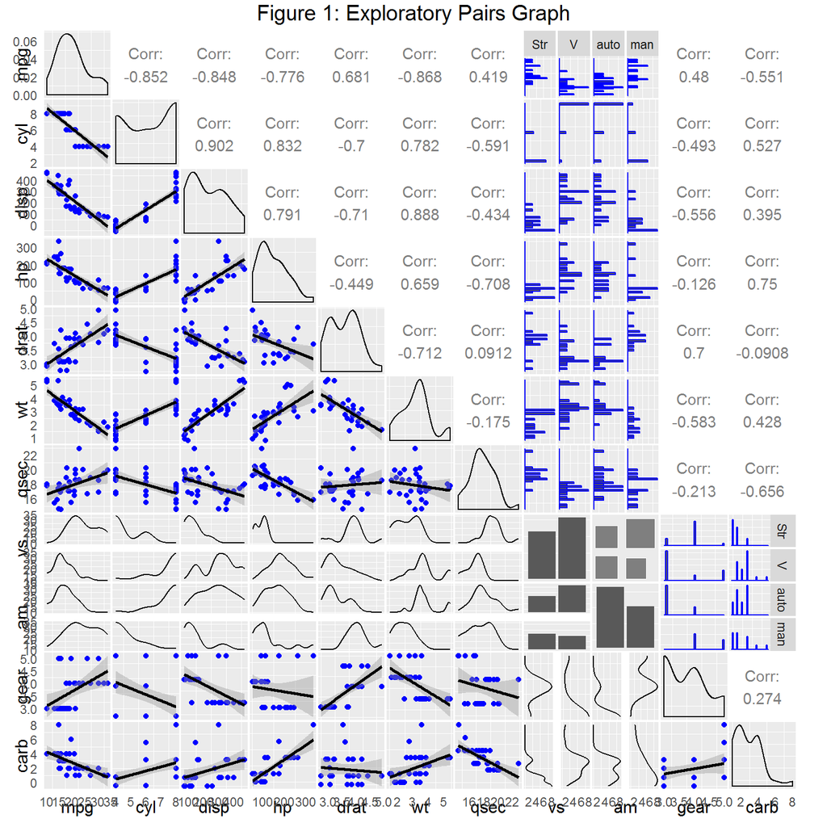

Looking at mileage based on weight, number of cylinders (as dot size) and transmission type we can see the data is not evenly distributed for automatic and manual transmissions.

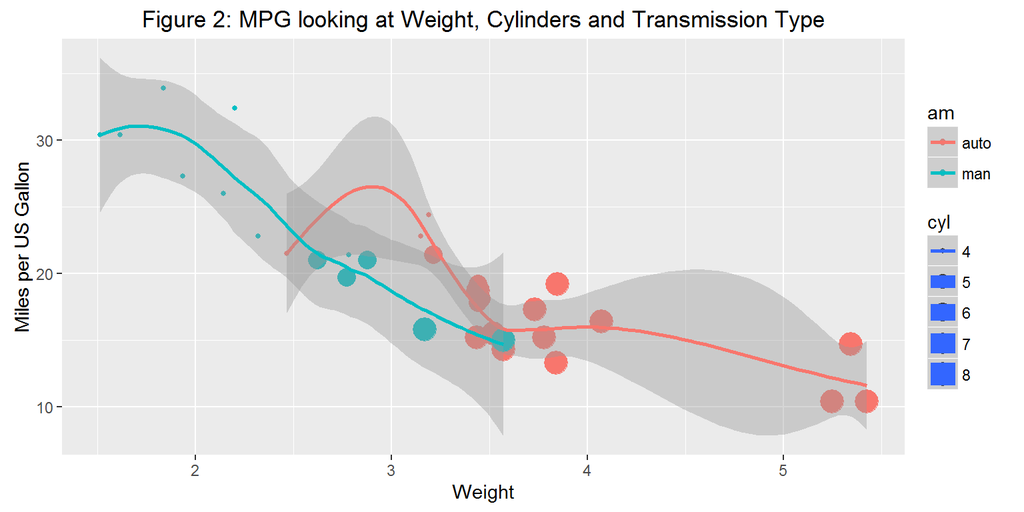

### Fitting and Selecting a Model

If we fit a linear model for mpg using only am as a regressor, the coefficients show the mean mileage for an automatic at 17.147mpg and that mileage increases by 7.245 mpg changing from automatic to manual. The P value for the difference from auto to manual 0.000285 is small so we can say the difference auto/manual is significant but in this model the $\it {R^2}$ is 0.359 so automatic/manual only explains about 36% of the variation in mpg for the data. We need a better model than this one.

```r
fit0 <- lm(mpg ~ factor(am), mtcars) ; summary(fit0)$coef
##                Estimate Std. Error   t value     Pr(>|t|)
## (Intercept)   17.147368   1.124603 15.247492 1.133983e-15
## factor(am)man  7.244939   1.764422  4.106127 2.850207e-04
```

If we fit a model using all the variables as regressors to predict mpg (knowing from the pairs plot that several of these are highly correlated) we can see from the square root of the variable inflation factor (VIF) - the increase in standard error - that this is not the right model either. We’ve gone from underfit to overfit.

```r
fitall <- lm(mpg ~ cyl + disp + hp + drat+ wt + qsec + factor(vs) + factor(am) + gear + carb, mtcars)
sqrt(vif(fitall))
##        cyl       disp         hp       drat         wt       qsec
##   3.920948   4.649757   3.135608   1.837014   3.894212   2.743712
## factor(vs) factor(am)       gear       carb
##   2.228424   2.156035   2.314617   2.812249
```

We can use the step function from the model with all the variables to find a more parsimonious fit at a lower standard error - resulting in a model predicting mpg from weight, qsec (acceleration) and auto/manual transmission.

```r
steps <- step(fitall, k=log(nrow(mtcars)), direction = "both", trace = FALSE)
summary(steps)
```

```
##
## Call:
## lm(formula = mpg ~ wt + qsec + factor(am), data = mtcars)
##
## Residuals:
##     Min      1Q  Median      3Q     Max
## -3.4811 -1.5555 -0.7257  1.4110  4.6610
##
## Coefficients:
##               Estimate Std. Error t value Pr(>|t|)
## (Intercept)     9.6178     6.9596   1.382 0.177915
## wt             -3.9165     0.7112  -5.507 6.95e-06 ***
## qsec            1.2259     0.2887   4.247 0.000216 ***
## factor(am)man   2.9358     1.4109   2.081 0.046716 *
## ---
## Signif. codes:  0 '***' 0.001 '**' 0.01 '*' 0.05 '.' 0.1 ' ' 1
##
## Residual standard error: 2.459 on 28 degrees of freedom
## Multiple R-squared:  0.8497, Adjusted R-squared:  0.8336
## F-statistic: 52.75 on 3 and 28 DF,  p-value: 1.21e-11
```

```r
fitbest <- lm(mpg ~ wt + qsec + factor(am), mtcars)
```

We can look at the step result using nested models. The first three variables weight, qsec and auto/manual reduce the residual sum of squares. Adding engine displacement to the fourth model does not reduce RSS much and is not statistically significant even though displacement is highly correlated to mpg.

```r
fit1 <- lm(mpg ~ wt, mtcars)
fit2 <- lm(mpg ~ wt + qsec, mtcars)
fit3 <- lm(mpg ~ wt + qsec + factor(am), mtcars)
fit4 <- lm(mpg ~ wt + qsec + factor(am) + disp, mtcars)
anova(fit1, fit2, fit3, fit4)
```

```
## Analysis of Variance Table
##
## Model 1: mpg ~ wt
## Model 2: mpg ~ wt + qsec
## Model 3: mpg ~ wt + qsec + factor(am)
## Model 4: mpg ~ wt + qsec + factor(am) + disp
##   Res.Df    RSS Df Sum of Sq       F  Pr(>F)
## 1     30 278.32
## 2     29 195.46  1    82.858 13.4762 0.00105 **
## 3     28 169.29  1    26.178  4.2576 0.04881 *
## 4     27 166.01  1     3.276  0.5328 0.47171
## ---
## Signif. codes:  0 '***' 0.001 '**' 0.01 '*' 0.05 '.' 0.1 ' ' 1
```

### Interpretation: Coefficients, Residuals and Uncertainty

```r
sqrt(vif(fitbest))
##         wt       qsec factor(am)
##   1.575738   1.168049   1.594189
confint(fitbest, level=0.95)
##                     2.5 %    97.5 %
## (Intercept)   -4.63829946 23.873860
## wt            -5.37333423 -2.459673
## qsec           0.63457320  1.817199
## factor(am)man  0.04573031  5.825944
```

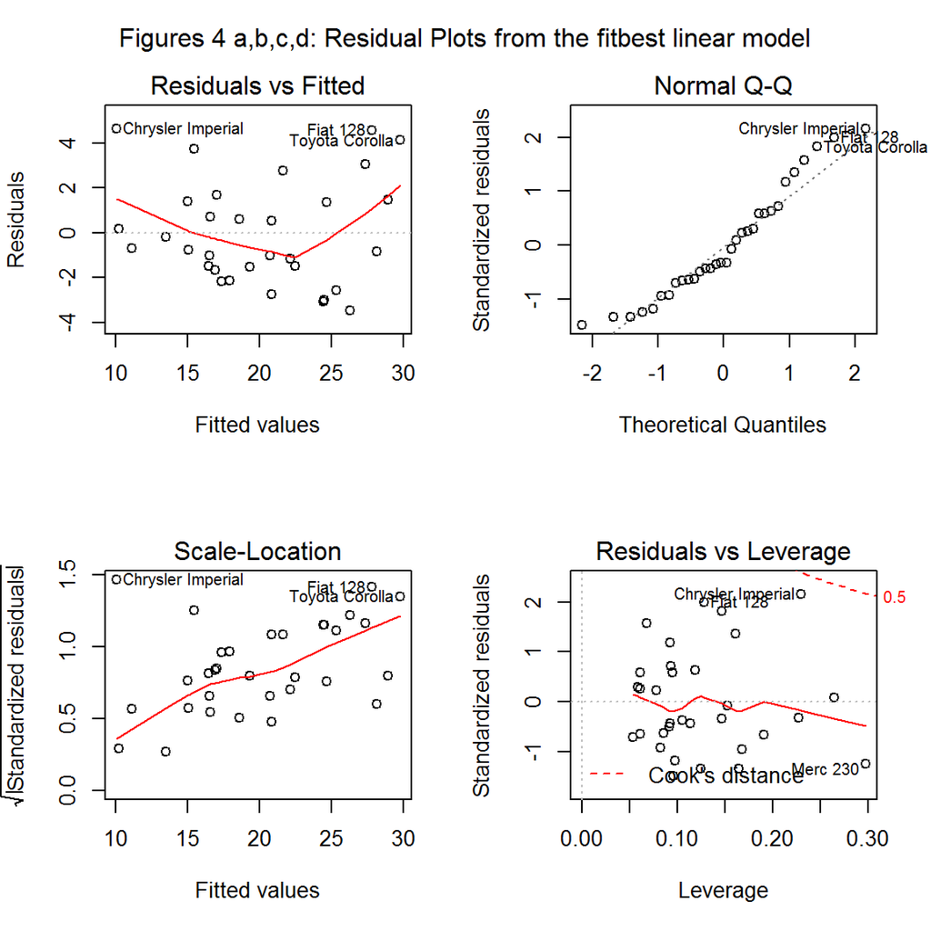

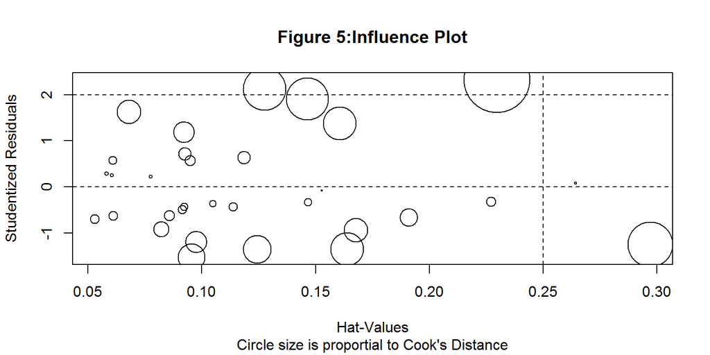

The R markdown is available on [Github](https://github.com/jrwalker-projects/RegressionModels) along with the markdown for the original course assignment pdf output. The pdf version deals with length constraints for the assignment where this version attempts to be more lucid.